# Homework 9

Kent Roller

2024-05-31

6. Continue the analysis of the Chile data set described in this chapter. The data set is in the “car” package, so you will have to install.packages() and library() that package first, and then use the data(Chile) command to get access to the data set. Pay close attention to the transformations needed to isolate cases with the Yes and No votes as shown in this chapter. Add a new predictor, statusquo, into the model and remove the income variable. Your new model specification should be vote ~ age + statusquo. The statusquo variable is a rating that each respondent gave indicating whether they preferred change or maintaining the status quo. Conduct general linear model and Bayesian analysis on this model and report and interpret all relevant results. Compare the AIC from this model to the AIC from the model that was developed in the chapter (using income and age as predictors).

```r
#Generalized Model (Logistic Regression)
library(car)
Chile <- Chile
ChileY <- Chile[Chile$vote == 'Y', ] # Grab the Yes votes
ChileN <- Chile[Chile$vote == 'N', ] # Grab the No votes
ChileYN <- rbind(ChileY, ChileN) # Make a new dataset with those
ChileYN <- ChileYN[complete.cases(ChileYN), ]
ChileYN$vote <- factor(ChileYN$vote, levels = c("N", "Y"))
ch.log.mod<-glm(formula=vote~age + statusquo, family= binomial(), data= ChileYN)
summary(ch.log.mod)
```

```
##
## Call:
## glm(formula = vote ~ age + statusquo, family = binomial(), data = ChileYN)
##
## Coefficients:
##              Estimate Std. Error z value Pr(>|z|)
## (Intercept) -0.193759   0.270708  -0.716   0.4741
## age          0.011322   0.006826   1.659   0.0972 .
## statusquo    3.174487   0.143921  22.057   <2e-16 ***
## ---
## Signif. codes:  0 '***' 0.001 '**' 0.01 '*' 0.05 '.' 0.1 ' ' 1
##
## (Dispersion parameter for binomial family taken to be 1)
##
##     Null deviance: 2360.29  on 1702  degrees of freedom
## Residual deviance:  734.52  on 1700  degrees of freedom
## AIC: 740.52
##
## Number of Fisher Scoring iterations: 6
```

```r
exp(coef(ch.log.mod))
```

```
## (Intercept)         age   statusquo
##   0.8238564   1.0113863  23.9145451
```

```r
table(round(predict(ch.log.mod, type='response')), ChileYN$vote)
```

```
##
##       N   Y
##   0 810  74
##   1  57 762
```

Interpretation of GLM:

We can examine the output above to compare this new model with the model we created in this chapter. As requested we have removed the income variable from the regression and have replaced it with the statusquo variable instead. The results show this to be a mixed bag of results but overall positive outcome. Using this method we see the variable age lose its significance in the regression versus the model age + income. However, statusquo is significant with a value close to zero, more than enough to satisfy a threshold of 0.05. We can also see that while NULL deviance remains roughly the same we see a large reduction in residual deviance, from 2326 down to 734.52. This is backed up by the fact that our AIC has also been drastically reduced from 2332 down to 740.52 making this a much better model, and indicating that statusquo is a much more reliable predictor of wether a person will vote Y/N than age or income. Lastly, looking at a confusion matrix output, we can again see a great reduction in the amount of both false positives and false negatives, giving us an accuracy of 92.3% compared to the previous models confusion matrix which resulted in an accuracy of ~56%. Again, all results indicate this a much better set of predictors.

```r
#Bayesian Analysis
library(MCMCpack)
ChileYN$vote<-as.numeric(ChileYN$vote)-1
bayes.log.mod<-MCMClogit(formula = vote ~ age + statusquo, data=ChileYN)
summary(bayes.log.mod)
```

```
##
## Iterations = 1001:11000
## Thinning interval = 1
## Number of chains = 1
## Sample size per chain = 10000
##
## 1. Empirical mean and standard deviation for each variable,
##    plus standard error of the mean:
##
##                 Mean       SD  Naive SE Time-series SE
## (Intercept) -0.18272 0.272640 2.726e-03       0.008938
## age          0.01123 0.006817 6.817e-05       0.000223
## statusquo    3.19061 0.145853 1.459e-03       0.004993
##
## 2. Quantiles for each variable:
##
##                  2.5%       25%      50%        75%   97.5%
## (Intercept) -0.742761 -0.365241 -0.17552 -0.0003872 0.34439
## age         -0.002005  0.006733  0.01121  0.0157683 0.02499
## statusquo    2.914442  3.087259  3.18546  3.2847388 3.48698
```

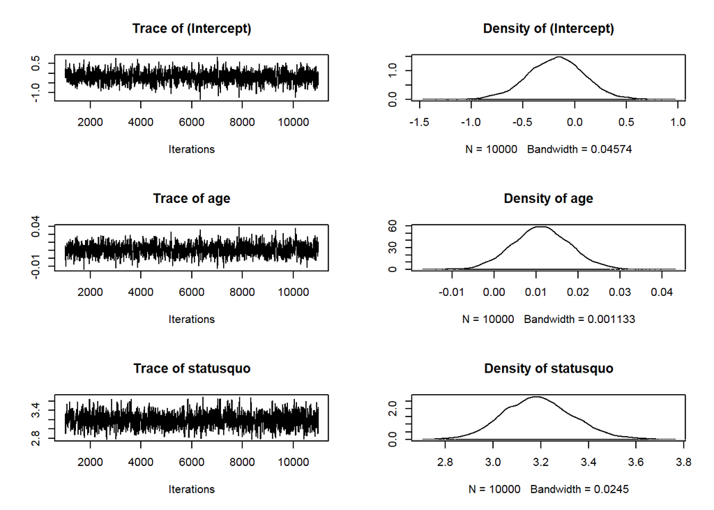

```r
plot(bayes.log.mod)
```

7. Bonus R code question: Develop your own custom function that will take the posterior distribution of a coefficient from the output object from an MCMClogit() analysis and automatically create a histogram of the posterior distributions of the coefficient in terms of regular odds (instead of log-odds). Make sure to mark vertical lines on the histogram indicating the boundaries of the 95% HDI.

```r
plot_posterior_odds <- function(mcmc_output, coefficient) {
  # Extract the posterior distribution for the specified coefficient
  log_odds <- as.matrix(mcmc_output[, coefficient])

  # Convert log-odds to regular odds
  odds <- apply(log_odds, 1, exp)

  # Create the histogram of the regular odds
  hist(odds, main = paste("Posterior Distribution of", coefficient, "in Regular Odds"),
       xlab = "Odds", ylab = "Frequency", col = "lightblue", border = "black")

  # Calculate the 95% HDI
  hdi_bounds <- quantile(odds, c(0.025, 0.975))

  # Add vertical lines for the 95% HDI
  abline(v = hdi_bounds[1], col = "black", lwd = 2, lty = 2) # Left edge of 95% HDI
  abline(v = hdi_bounds[2], col = "black", lwd = 2, lty = 2) # Right edge of 95% HDI
}
```

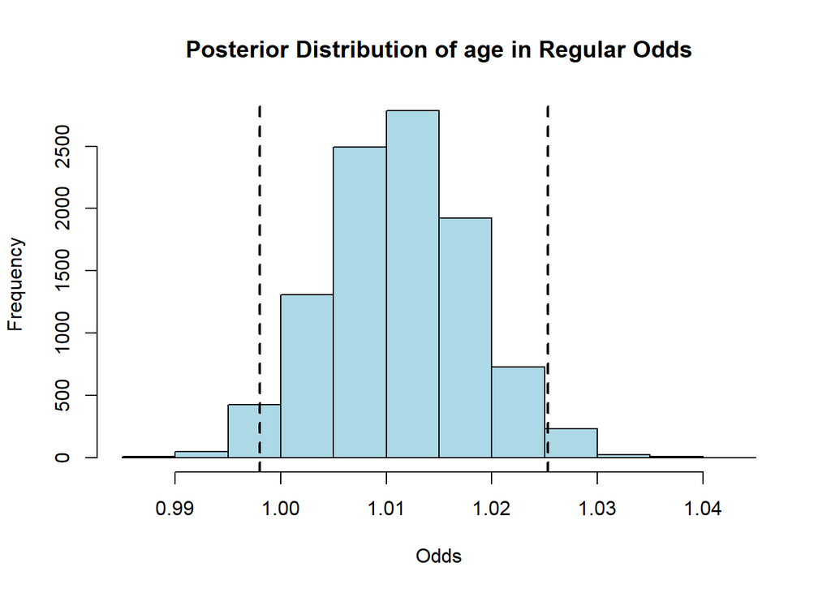

```r
plot_posterior_odds(bayes.log.mod, 'age')
```

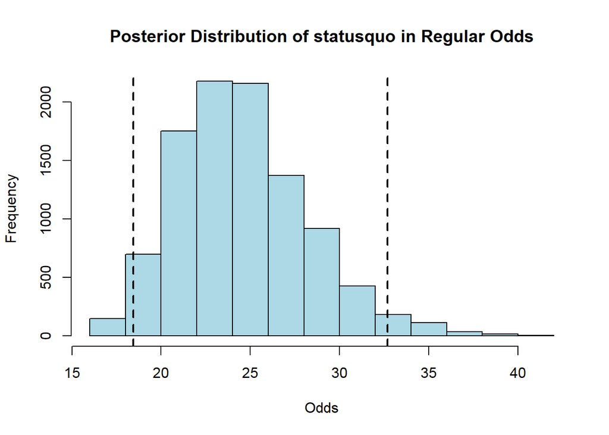

```r
plot_posterior_odds(bayes.log.mod, 'statusquo')
```